# Car Prices for Dummys

Dustin Leatherman, Kyra Kemp, Danielle Deng, Zhichun Ke

11/16/2019

# Introduction

# The Data

> This dataset is a representative sample of over eight hundred 2005 GM cars from the Kelly Blue Book.

Due to the right-skewed nature of Price, a log transformation has been applied and displayed alongside for comparison.

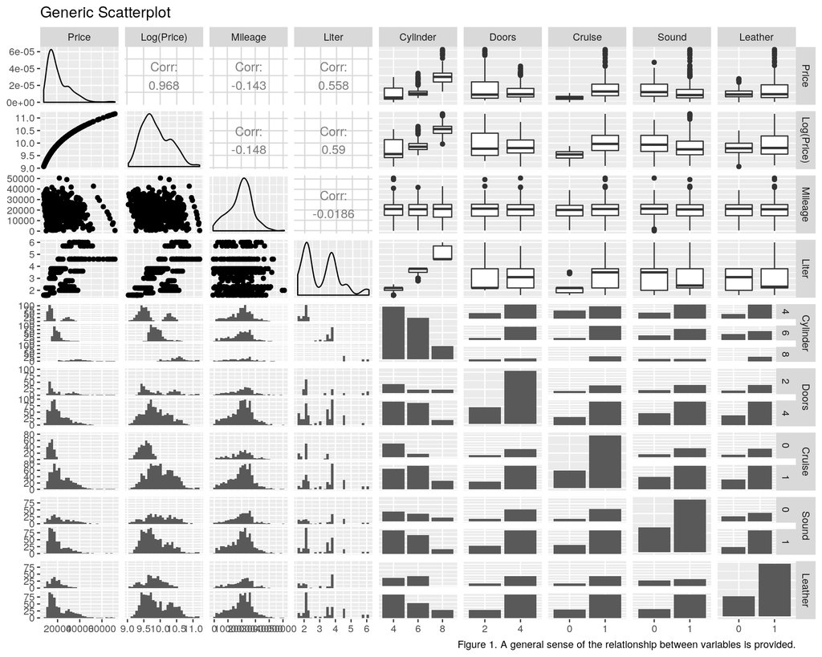

# Summary (cont.)

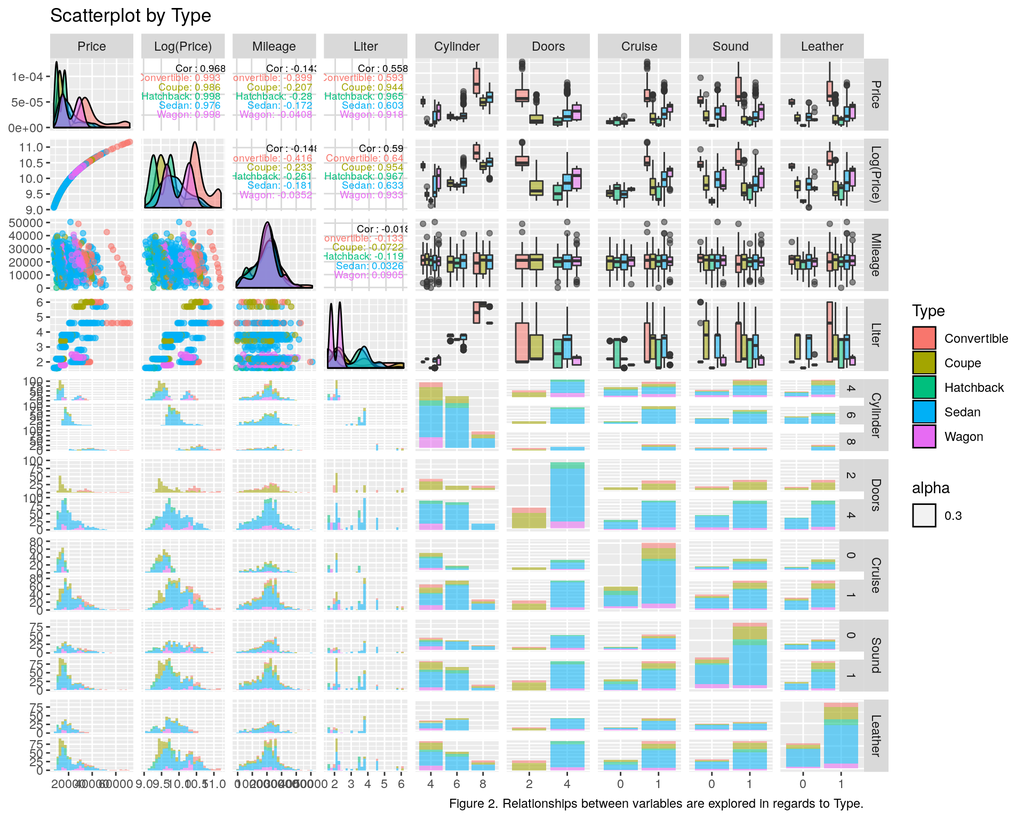

# Summary (cont.)

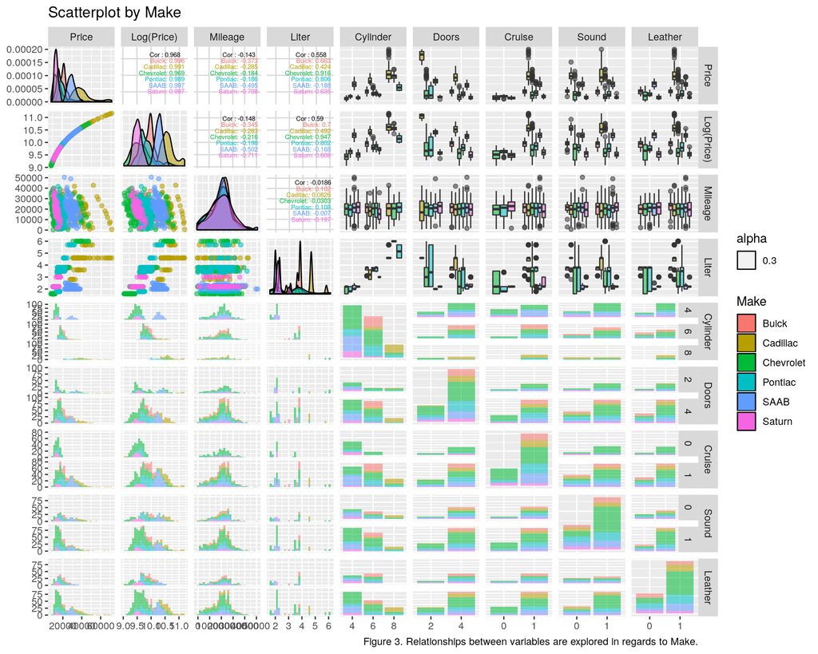

# Analysis

Prior to fitting any model, a full model will be fit first in order to ensure that model assumptions are correct.

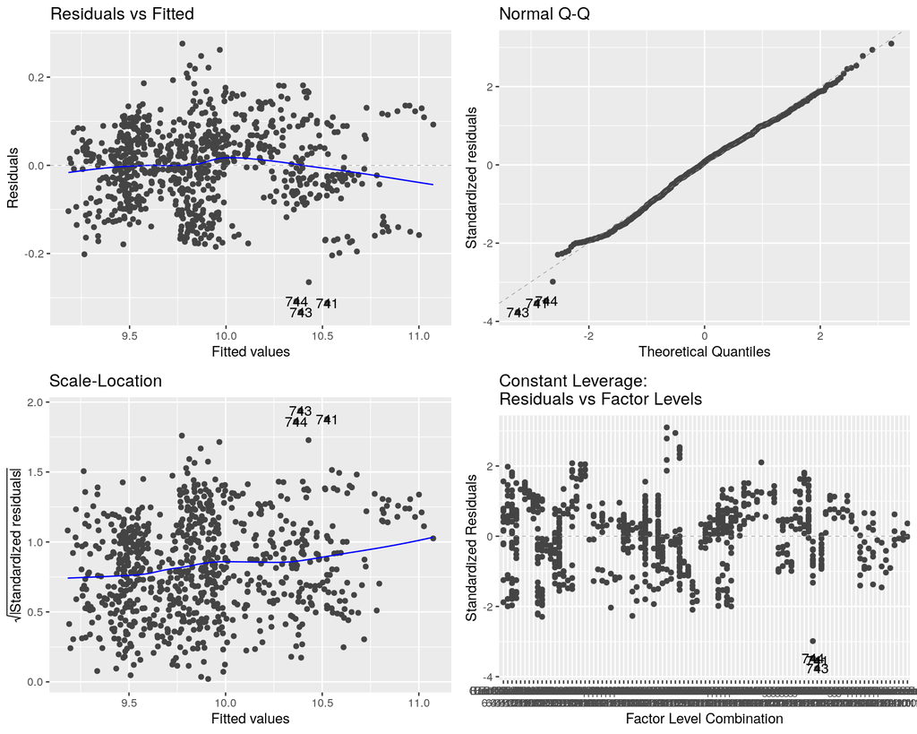

### Normality

The residuals are close to the line barring a few outliers on the left tail. From a visual perspective, data appear normal but a Shapiro-Wilk test indicates there is convincing evidence that the data is non-normal (p-value = 0.002606). There are three outliers identified on the left tail that may be influencing this outcome. This must be explored.

| statistic | p.value | method |
| --- | --- | --- |
| 0.9939636 | 0.0026057 | Shapiro-Wilk normality test |

### Linearity

There do not appear to be any patterns in the residuals indicating that a linear regression model is appropriate for the data.

### Constant Variance

The spread around y = 0 on the Residuals vs Fitted plot appears to be constant barring the same potential outliers present in the normal probability plot; however, the Brown-Forsyth test indicates that there is convincing evidence that the variance is not constant (p-value = 0.00016).

| statistic | p.value | method |
| --- | --- | --- |
| 14.33485 | 0.0001644 | Modified robust Brown-Forsythe Levene-type test based on the absolute deviations from the median |

| x |
| --- |
| 0.9578966 |

```
## Model :
## log.price ~ Mileage + Make + Type + Liter + cylinder.factor +
##     doors.factor + cruise.factor + sound.factor + leather.factor
##
## Complete :
##               (Intercept) Mileage MakeCadillac MakeChevrolet MakePontiac
## doors.factor4 0           0       0            0             0
##               MakeSAAB MakeSaturn TypeCoupe TypeHatchback TypeSedan TypeWagon
## doors.factor4 0        0          0         1             1         1
##               Liter cylinder.factor6 cylinder.factor8 cruise.factor1
## doors.factor4 0     0                0                0
##               sound.factor1 leather.factor1
## doors.factor4 0             0
```

There is multicollinearity present due to the high correlation between Liter and Cylinder. (see *Figure 1*). This further confirmed given a correlation coefficient of 0.958. Additionally, the **Doors** predictor is linearly dependent on the Indicator variables TypeWagon, TypeHatchback, and TypeSedan. This means that this coefficient cannot be estimated and thus should be removed from the model.

| .rownames | GVIF | Df | GVIF..1..2.Df.. |
| --- | --- | --- | --- |
| Mileage | 1.008172 | 1 | 1.004078 |
| Make | 8.933621 | 5 | 1.244809 |
| Type | 2.937632 | 4 | 1.144194 |
| Liter | 19.558325 | 1 | 4.422479 |
| cylinder.factor | 39.557783 | 2 | 2.507887 |
| cruise.factor | 1.587586 | 1 | 1.259994 |
| sound.factor | 1.151701 | 1 | 1.073173 |
| leather.factor | 1.247231 | 1 | 1.116795 |

| .rownames | GVIF | Df | GVIF..1..2.Df.. |
| --- | --- | --- | --- |
| Mileage | 1.007870 | 1 | 1.003927 |
| Make | 4.091844 | 5 | 1.151309 |
| Type | 2.246857 | 4 | 1.106488 |
| Liter | 1.876033 | 1 | 1.369684 |
| cruise.factor | 1.552723 | 1 | 1.246083 |
| sound.factor | 1.136262 | 1 | 1.065956 |
| leather.factor | 1.196471 | 1 | 1.093833 |

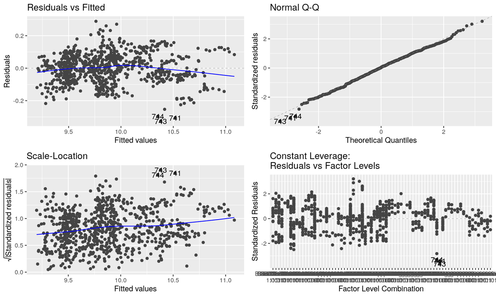

| statistic | p.value | method |
| --- | --- | --- |
| 0.9969428 | 0.1304873 | Shapiro-Wilk normality test |

| statistic | p.value | method |
| --- | --- | --- |
| 4.59833 | 0.032303 | Modified robust Brown-Forsythe Levene-type test based on the absolute deviations from the median |

The data appears more normal now (Shapiro-Wilk Test. p-value = 0.1305) but there is still moderate evidence of non-constant variance (Brown-Forsythe. p-value = 0.0323).

## Question 1

> How does Type, Cylinder, and Liter affect average Price? How does this change when Mileage is taken into account?

# Appendices

| Variable | Description |
| --- | --- |
| Price | suggested retail price of the used 2005 GM car in excellent condition. The condition of a car can greatly affect price. All cars in this data set were less than one year old when priced and considered… |
| Mileage | number of miles that the car has been driven. |
| Make | manufacturer of the car such as Saturn, Pontiac, and Chevrolet. |
| Model | Specific models for each car manufacturer such as Ion, Vibe, Cavalier. |
| Trim | Specific type of car model suc has SE Sedan 4D, Quad Coupe 2D. |
| Type | Body type such as sedan, coupe, etc. |
| Cylinder | Number of cylinders in the engine. |
| Liter | A more specific meaasure of engine size. |
| Doors | Number of doors |
| Cruise | Indicator representing whether the car has cruise control (1 = cruise). |
| Sound | Indicator representing whether the car has upgraded speakers (1 = sound). |
| Leather | Indicator representing whether the car has leather seats (1 = leather). |